# Evaluación del estado del conocimiento oceánico a partir de una base de metadatos: fortalezas, limitaciones y aplicación a México

Juliano Palacios-Abrantes, Andrés Cisneros-Montemayor, Miguel Ángel Cisneros-Mata, Laura Rodríguez, Francisco Arreguín-Sánchez, Santiago Domínguez-Sánchez, Verónica Aguilar, Raquel López-Sagástegui, Hector Reyes, Rocío Rivera, Silvia Salas, Stuart Fulton, Nuno Simoes y William Cheung

5/2019

- **NOTA: esta es una traducción del artículo** *A metadata approach to evaluate the state of ocean knowledge: Strengths, limitations, and application to Mexico* escrito por Juliano Palacios-Abrantes, Andrés Cisneros-Montemayor, Miguel Ángel Cisneros-Mata, Laura Rodríguez, Francisco Arreguín-Sánchez, Santiago Domínguez-Sánchez, Verónica Aguilar, Raquel López-Sagástegui, Hector Reyes, Rocío Rivera, Silvia Salas, Stuart Fulton, Nuno Simoes y William Cheung. El artículo original se puede encontrar en el siguiente *[link](https://doi.org/10.1371/journal.pone.0216723)*.
- **Palacios-Abrantes J.**, Cisneros-Montemayor, A. M., Cisneros-Mata, M. A., Rodriguez, L., Arreguín-Sánchez, F., Aguilar, V., Domínguez-Sánchez, S., Fulton, S., López-Sagástegui, R., Reyes-Bonilla, H., Rivera-Campos, R., Salas, S., Simoes, N., and Cheung, W. W. L., 2019. A metadata approach to evaluate the state of ocean knowledge: Strengths, limitations, and application to Mexico. PLoS ONE, 14 (6), e0216723.

Descargar traducción en PDF

# Resumen

El cambio climático, el mal manejo en la extracción de recursos y la contaminación ambiental están cambiando los ecosistemas marinos y repercutiendo directamente en la sociedad. El desarrollo marino sustentable requiere conocimiento y datos de múltiples disciplinas, escalas y tipos del conocimiento. Si bien varias disciplinas están generando vastas cantidades de datos de sistemas marinos socio-ecológicos, dicha información está constantemente subutilizada debido a fragmentación de relaciones entre usuarios y/o instituciones, falta de estandarización de información a nivel de escala, tiempo y espacio, así como el hecho de que muchas veces resulta virtualmente imposible encontrar la información en los buscadores disponibles. La colecta de metadatos, la información que describe a los datos, es una herramienta efectiva para resolver esta problemática, sobre todo cuando se pueden combinar metadatos de distintas disciplinas y bases de datos para integrar, organizar y clasificar datos multidisciplinarios. En el presente proyecto se hizo un estudio del caso de México para crear una base de metadatos de investigación marina con el objetivo de mejorar el acceso a la información, facilitar la integración e intercambio de datos multidisciplinarios, así como fomentar la colaboración entre partes interesadas. Adicionalmente, se evaluaron las tendencias y faltas de información para apoyar el manejo de recursos marinos en México. El análisis reveló un claro enfoque ecológico y pesquero de la investigación marina, con datos biológicos más consistentes a lo largo del tiempo y espacio en comparación de datos sociales. También fueron evidentes diferencias por región. La mayoría de la información recopilada correspondió al Golfo de California, Pacífico norte, Banco de Campeche y Caribe, con una evidente falta de información en el centro y sur del Pacífico, así como la parte oeste del Golfo de México. Pese a algunos vacíos de información en México y otros lugares, los análisis sistemáticos como el presente pueden revelar una gran cantidad de información y ponerla a disposición de tomadores de decisiones para elaborar políticas públicas claves para lograr metas nacionales e internacionales de gestión marina sustentable. Tan sólo con un enfoque transdisciplinario se lograrán superar los desafíos sociales y ecológicos a diferentes escalas, tanto presentes como futuros, y alcanzar un uso sustentable de los recursos naturales. Las bases de metadatos son herramientas fundamentales para hacer un mejor uso de datos existentes, determinar fortalezas y abatir deficiencias, y para desarrollar escenarios que sirvan de insumo en el desarrollo de políticas para la gestión de sistemas socio-ecológicos marinos complejos.

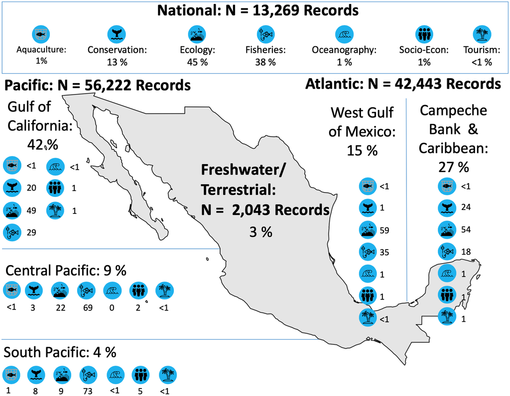

**Localización geográfica de los metadatos recolectados por subregión y disciplina determinadas en la base de metadatos.** https://doi.org/10.1371/journal.pone.0216723.g005

# Introducción

El océano proporciona una gran variedad de bienes y servicios ecosistémicos como alimento, energía y rutas de transporte, además de ser una fuente de valores culturales y recreativos [1,2]. Sin embargo, el cambio climático, la extracción excesiva de recursos marinos, la contaminación y demás actividades humanas están afectando la biodiversidad marina mundial y los servicios ecosistémicos [3–6] e impactando negativamente estructuras sociales y económicas [7]. Para mitigar y gestionar estos impactos humanos y promover el uso sustentable de los recursos marinos se requieren datos de distintas disciplinas, que cubran largos intervalos de tiempo y diferentes escalas geográficas. Para elaborar políticas públicas eficientes que permitan evaluar el estado de la investigación marina y establecer objetivos claros de manejo de los recursos se requiere diversas fuentes de información complementarias [8]. Este enfoque multidisciplinario ha sido adoptado por alianzas internacionales que buscan alcanzar los Objetivos del Desarrollo Sostenible de las Naciones Unidas (UN-SDGs[^1]) [9]. A pesar del llamado global de transitar hacia el desarrollo de “ciencia abierta” y los beneficios derivados de compartir datos y métodos y las colaboraciones son más comunes [10], la identificación, el acceso y el intercambio de datos siguen siendo un desafío en todo el mundo [11].

Los metadatos, es decir la información requerida para entender los datos, como el tipo, contenido, fuente, calidad, formato, estructura y accesibilidad, son importantes para la armonización de datos a través de escalas, disciplinas y dominios [10,12]. Los repositorios de metadatos (y su propio desarrollo) tienen la capacidad de mejorar el acceso a los datos, fomentar la colaboración entre las partes interesadas y facilitar los análisis posteriores, así como el refinamiento de los datos [13,14]. Varios campos de investigación relacionados con sistemas marinos socio-ecológicos han generado grandes cantidades de datos. Sin embargo, dichos datos no están estandarizados y se encuentran dispersos, en diferentes instituciones y su localización y acceso es constreñido, por lo que a menudo son poco utilizados [6,8,15]. Los metadatos son particularmente útiles para los países en desarrollo con capacidad de investigación limitada [11] y donde existen datos, pero se los considera restringidos o no disponibles [16].

Hoy en día existen repositorios de datos y metadatos nacionales para sistemas marinos en Australia [17], Canadá [13] y las Islas Canarias en España [18]. El Sistema Integrado de Observación Marina (IMOS) de Australia es un proyecto de investigación que opera a nivel nacional e incluye una base de datos que permite a los usuarios ver gráficos dinámicos, así como ingresar y acceder a datos y metadatos [17]. Dicha base de datos ha dado lugar a cientos de publicaciones científicas, capítulos de libros y reportes [19]. En Canadá [13] se creó un repositorio de metadatos con el objetivo de identificar brechas temáticas y de información en la investigación marina para las regiones ártica, pacífica y atlántica. Posteriormente dicho repositorio se utilizó en la evaluación del progreso del país hacia el Convenio sobre la Diversidad Biológica: Objetivos de Aichi (CDB [^CBD] ) [14]. El repositorio de datos marinos de las Islas Canarias (REDMIC) incluye datos, metadatos, documentos de investigación, mapas y gráficos interactivos relacionados con el ambiente marino, que han respaldado la toma de decisiones y la investigación regional [18]. Todas estas iniciativas tienen como objetivo aumentar el acceso a los datos, apoyar la investigación de metadatos y mejorar la toma de decisiones relacionadas con las políticas ambientales marinas a partir de un soporte científico.

En este estudio se desarrolló un marco de referencia para la elaboración de una base interdisciplinaria de metadatos para sistemas marinos, con el objetivo de apoyar la toma de decisiones para el desarrollo sostenible de los océanos mediante la evaluación del estado de la información existente, así como la determinación de vacíos y tendencias de investigación. Aplicamos este marco a México como ejemplo de una nación en desarrollo con extensas costas y área marina [15]. Al igual que en otras partes del mundo, múltiples organizaciones académicas (p.g. instituciones públicas de investigación [20]), gobierno [21], organizaciones de la sociedad civil (OSC) [22], e instituciones privadas generan y albergan una gran cantidad de datos de múltiples campos de investigación. Sin embargo, la información sobre estos datos y los datos en sí no siempre están visibles o accesibles, ni se pueden buscar en un formato estandarizado. Debido a esto, investigadores y gestores de recursos pueden no estar enterados de proyectos pertinentes a su campo realizados en años anteriores o incluso que sigan en curso. Asimismo, en varias ocasiones los políticos encargados de la creación e implementación de políticas públicas de manejo de recursos se ven limitados por la disponibilidad de información (tanto temporal como espacial). Estas limitaciones se pueden abordar mediante un esfuerzo colaborativo.

En el presente estudio se describen los procesos de diseño, compilación y métodos para vincular y armonizar conjuntos de datos de diferentes escalas y dominios en una base de metadatos, y se presentan ejemplos de análisis de metadatos como tendencias históricas, regionales y temáticas. Crear y mantener un repositorio de metadatos de acceso abierto puede facilitar la interpretación de la información a través de consultas públicas y el intercambio de datos. Los análisis de metadatos son críticos para ayudar a identificar falta de datos y promover la creación de redes de colaboración entre una amplia gama de individuos, instituciones y organizaciones.

# Materiales y Métodos

El proceso de desarrollo de la base de metadatos de investigación marina para México (MDB) constató de cuatro etapas: (*1*) desarrollo de la estructura de la MDB; (*2*) identificación, comunicación y colecta de metadatos y repositorios disponibles; (*3*) elaboración de protocolos para la inclusión y distribución de metadatos; (*4*) publicación de la MDB como una plataforma accesible, pública y estable a través del tiempo mediante de una institución externa (en esta caso la Comisión Nacional para el Conocimiento y uso de la Biodiversidad, CONABIO [23]). Posteriormente se presentan algunos ejemplos de análisis que se pueden realizar a partir de una base de metadatos mediante la identificación de tendencias y vacíos de información. La base de metadatos de investigación marina en México (infocéanos) puede encontrarse en http://infoceanos.conabio.gob.mx/.

## Estructura de la base de metadatos

Existen cinco niveles en la estructura de la MDB: Base de metadatos > Repositorio > Base de datos > Registro > Dato

Existen cinco niveles en la estructura de la MDB: Base de metadatos > Repositorio > Base de datos > Registro > Dato ([Fig 1](https://doi.org/10.1371/journal.pone.0216723.g001)). La base de metadatos incluye los metadatos de los datos mientras que los repositorios son estructuras que contienen múltiples bases de datos. Los repositorios pueden estar en línea (v.g. Ocean Biogeographic Information System (OBIS) [24]), reportes de algún tema en específico (v.g. el anuario estadístico de pesca de SAGARPA-CONAPESCA [25]), o repositorios institucionales, de algún laboratorio o proyecto de investigación que comprenda múltiples bases (v.g. el catálogo de especies marinas en México del Instituto de Ciencias del Mar y Limnología de la UNAM [26]). Los registros de metadatos son individuales y describen cada dato dentro de una base de datos (v.g. Captura de almejas en la región A o Captura de almejas en la región B; Fig 1). Los metadatos contienen descripciones de los datos mas no los datos; en metadatos marinos, dicha información puede ser relacionada a captura pesquera, distribución de especies, o costo de pesca. Finalmente, un dato es un punto de información dentro de un registro. Por ejemplo, un registro de abundancia anual de la población de cierta especie entre 2000 y 2003 incluye cuatro (promedio anual) datos de abundancia estimada. Los registros contemplan la escala espacial y temporal; por ejemplo, las capturas pesqueras pueden ser registradas a nivel regional o nacional.

## Categorías de los Metadatos

El contar con una estructura de metadatos estandarizada proporciona un marco de referencia para que la información incorporada sea consistente en sujetos (v.g. almejas, atunes, pulpos) y tipos de información (v.g. métodos, unidades de medida y detalles del diseño experimental) [12,17,27]. En el presente estudio se asignaron campos de metadatos con el objetivo de maximizar la flexibilidad de la base para acomodar datos multidisciplinarios y permitir una serie de meta-análisis. Inicialmente se adoptó la estructura de la base de metadatos marinos desarrollada para Canadá [13]; posteriormente ésta fue modificada (principalmente para acomodar la geografía y clasificación de especie de acuerdo con estándares nacionales) y finalmente se incorporaron sugerencias proporcionadas por diversos expertos nacionales en temas marinos. Las sugerencias fueron proporcionadas en varias reuniones descritas en la sección *Colección de Metadatos*. La principal diferencia entre la estructura de la MDB y la preparada para Canadá es que en ésta última cada registro de metadatos representa un repositorio específico (v.g. un reporte o una base de datos) con un campo de la estructura de la base que indica el número de series de tiempo dentro del registro. En la MDB, cada serie de tiempo es un registro de metadatos únicos y en diferentes campos de la estructura se denotan la base de datos y el repositorio al que pertenecen. Si bien esta estructura requiere mayor esfuerzo de inclusión de registros, el producto final es una base de metadatos que se puede analizar más fácilmente y que permite mayor detalle en cada registro. La estructura final de la MDB incluye 29 categorías, desde información general como región o sujeto de estudio, hasta información más específica como número de puntos de datos en la base y/o disciplina ([Tabla S1 en Suplementos](https://doi.org/10.1371/journal.pone.0216723.s001)).

## Colecta de metadatos

La primera etapa de colecta constó en capturar la información disponible en repositorios públicos en línea, como OBIS [28] o las estadísticas pesqueras de la Organización Mundial para la Alimentación (UN-FAO) [29], catálogos estadísticos nacionales como el de pesca [25] y bases de datos producidas y/o albergadas por universidades u OSC que trabajan con el ambiente marino. Posteriormente, utilizamos esta primera versión de la base como plataforma de discusión en 20 talleres (~30 personas por taller), con grupos de investigación universitarios, gubernamentales y pertenecientes a OSC en ocho ciudades localizadas en distintas regiones de México [(Fig 2)](https://doi.org/10.1371/journal.pone.0216723.g002). La última etapa constó en realizar reuniones en persona y virtuales, así como presentaciones en conferencias nacionales e internacionales para mostrar el avance de la base y promover la colaboración entre instituciones ([Tabla S2 en Suplementos](https://doi.org/10.1371/journal.pone.0216723.s002)). Para unificar esfuerzos, nos reunimos con cuatro instituciones gubernamentales (CONACyT- Consejo Nacional de Ciencia y Tecnología [30], INAPESCA - Instituto Nacional de Pesca y Acuacultura [31], INECC - Instituto Nacional de Ecología y Cambio Climático [32] y CONABIO [23]), así como encargados de repositorios ya existentes (dataMares [33] y Monitoreo Noroeste [34]). Cabe mencionar que si bien esto representa un esfuerzo importante, no cubre todas las fuentes de datos en México; de ahí la importancia de continuar con este trabajo.

## Tipos de fuentes de datos

Se incluyó todo tipo de fuentes de datos en la MDB. En la primera etapa se buscó incorporar toda la información públicamente disponible en línea relacionada con el medio marino mexicano. Estas fuentes incluyeron datos de instituciones académicas, gubernamentales, OSC relacionadas con el medio ambiente y privadas (personal no académico o de la industria), tanto nacionales como internacionales. Asimismo, se buscó recolectar información sobre datos aún no publicados o mantenidos en formatos no digitales. La siguiente sección señala algunas de las instituciones que contribuyeron con información a la MDD.

### Academia

Las fuentes de datos académicos comprenden bases de datos administradas por instituciones académicas públicas y privadas de México. Algunas de las fuentes que comparativamente aportaron muchos datos incluyen el Atlas Climático de México manejado por la UNAM [35] el cual posee una extensa base de variables fisicoquímicas usadas en modelos de cambio climático, entre otras cosas. La unidad académica de la UNAM en Sisal, Yucatán (UNAM-UAY) proporcionó información de diversos temas como oceanografía, ecología, pesquerías, biología y turismo [36]. Finalmente, el Centro de Investigación y Estudios Avanzados del Politécnico Nacional (CINVESTAV-IPN) contiene una extensa fuente de información relacionada principalmente con la pesca y el turismo en la península de Yucatán [37].

### Instituciones gubernamentales

El gobierno mexicano dio un paso sin precedentes hacia la transparencia de datos con el decreto de 2015 en el cual se establece la política nacional a través del portal Datos Abiertos MX en donde se encuentran miles de bases de datos institucionales [38,39]. Si bien el portal contiene sólo un porcentaje de la vasta información que distintas dependencias han recolectado en décadas de programas públicos, representa una fuente de más de 500 bases de datos relacionadas con corrupción, desarrollo económico, servicios públicos, cambio climático y derechos humanos, entre otros [39]. A pesar de que algunos de estos datos no están relacionados directamente con el ambiente marino, siguen siendo fundamentales para la elaboración de políticas públicas sobre sistemas socio-ecológicos marinos. La transición hacia el portal de Datos Abiertos MX no ha sido completa y diversas instituciones mantienen sus portales de datos. Este es el caso de la Secretaría de Economía [40], CONAPESCA [25] y CONABIO [41], entre otros. Toda la información de éstas y otras instituciones destacadas en la base de metadatos están públicamente disponibles para consulta en forma de reportes, portales de internet y anuarios.

### Organizaciones de la Sociedad Civil (OSCs)

Las OSC en México tienen datos de pesquerías, conservación, oceanografía y sociología. En la base de metadatos, la OSC Comunidad y Biodiversidad, A.C. (COBI) representa el mayor repositorio. Dicha organización tiene como objetivo conservar los ecosistemas marinos que se están deteriorando debido a la sobreexplotación de recursos y cuenta con varios programas de monitoreo que comprenden más de dos décadas [22]. El proyecto *Monitoreo Noroeste* del Fondo Mexicano para la Conservación de la Naturaleza es el segundo repositorio con mayor cantidad de registros en la MDB y a su vez representa un repositorio con más de 1,000 bases de datos de monitoreo en el noroeste mexicano proveniente de 20 OSC [34].

### Fuentes académicas internacionales

Algunos grupos de investigación internacionales contienen una gran variedad de datos de México, en particular estudios a nivel global; dataMares y OBIS son los principales repositorios internacionales en la MDB. dataMares es una plataforma de datos abiertos con sede en el instituto de oceanografía *Scripps* de la Universidad de California, San Diego [33]. Dicho programa tiene como objetivo albergar y facilitar el acceso a datos científicos relacionados con las costas mexicanas. OBIS es una plataforma global de datos abiertos relacionados con biodiversidad (en este caso marina) [24]. El Museo del Desierto de Arizona-Sonora contiene un listado extensivo de invertebrados del Golfo de California; la Universidad de British Columbia en Canadá tiene más de tres mil registros relacionados con economía pesquera, modelos de cambio climático para los océanos, y proyecciones futuras de abundancia y captura para alrededor de 200 especies que ocurren a nivel nacional. Dichos datos están concentrados en las unidades de investigación *Changing Ocean Research Unit* [42] y *Fisheries Economic Research Unit* [43]. Finalmente, FishBase [44] y SeaLifeBase [45] son bases de datos en línea que proporcionan diversa información ecológica (v.g. historia de vida, ecología trófica, dinámica poblacional) para más de dos mil especies que ocurren en México.

## Análisis de metadatos

El análisis de la MDB fue realizado con el programa *R-Studio (R) Version 1.1.463* y paquetes *data.table* [46] y *tidyverse* [47]. Las categorías de metadatos fueron comparadas por números totales y porcentajes disponibles por disciplina e incluyeron la distribución espacial y temporal de los registros, la cantidad de registros por *taxa*, disciplina y tipo de fuente de datos así como la relación socio-ecológica de los metadatos. Todas las figuras fueron producidas utilizando los siguientes paquetes de *R*: *ggplot2* [48], *cowplot* [49], *ggpubr* [50], *ggrepel* [51], *gridExtra* [52] y *wesanderson* [53].

Para el análisis espacial se utilizaron los paquetes *ggplot2* [48] y *sf* [54] y el mapa de México se obtuvo de *Natural Earth* (http://naturalearthdata.com). Existen diversas categorías espaciales para los océanos mexicanos. La CONABIO considera cinco eco-regiones marinas en México mientras que la CONAPESCA establece seis regiones de pesca nacionales, por lo que se estandarizó la zona económica exclusiva de México para armonizar datos de distintas fuentes [(Fig 2)](https://doi.org/10.1371/journal.pone.0216723.g002). También se estandarizaron los nombres en la categoría de Sujeto de investigación (*taxa*); los nombres comunes se modificaron para reflejar el objeto principal (v.g. “camarón” se utilizó para incluir “*shrimp*”, “camarones”, “camarón sin cabeza”, etc.) y los nombres científicos fueron homologados y corregidos con el paquete *taxize* [55].

El análisis de tendencias temáticas fue hecho a partir del número de registros en la MDB, así como la cantidad de puntos de datos (años de datos) disponibles durante los años de colecta de cada registro. Todos los registros fueron catalogados de acuerdo con su interacción socio-ecológica de acuerdo con el marco de referencia de DPSIR (*Drivers*: Causantes, *Pressures*: Presión, *State*: Estado, *Impacts*: Impactos, y *Response*: Respuestas) [56]. De acuerdo con DPSIR, los Beneficios representan beneficios sociales provenientes de los sistemas naturales (v.g. capturas pesqueras), Presión (que se juntaron como agentes causantes) representan cualquier presión al sistema natural por parte del social (v.g. esfuerzo de pesca), Respuesta considera cualquier acción que reduce la Presión (v.g. limitar el esfuerzo pesquero) y Estado se refiere al estado actual de los sistemas naturales (v.g. evaluaciones). Se utilizó el paquete *networkD3* [57] para analizar la relación entre registros, instituciones, disciplinas y DPSIR. Finalmente, se empleó la prueba de *Chi* cuadrada [58] para investigar diferencias significativas en el número de registros entre distintas variables.

Es posible que existan bases de datos repetidas en la MDB. Sin embargo, debido al tamaño de la MDB y el esfuerzo que se hizo para identificarlas no se espera que las repeticiones constituyan un problema. Se utilizó R para automatizar e identificar fuentes de información redundante (v.g. instituciones que tienen la misma base de datos) y se consultó, cuando fue posible, a curadores y dueños si alguna de sus bases de datos estaba publicada en otros repositorios. Los registros que presentan la misma base de datos (v.g. Capturas pesqueras de CONAPESCA y dataMares) pero con distinto nivel de procesamiento (v.g. distintos niveles taxonómicos o anuales) no fueron considerados como duplicados y se mantuvieron como registros diferentes.

# Resultados

Fuentes internacionales (v.g. Global Biodiversity Information Facility-GBIF, dataMares, OBIS) contienen la mayor cantidad de registros para México (49%), aunque cabe mencionar que estas fuentes incluyen datos recolectados por investigadores mexicanos, en instituciones mexicanas y/o fueron apoyadas económicamente por el gobierno mexicano [59,60]. En general, en México, predominan los metadatos provenientes de instituciones académicas (sin importar la disciplina) y gubernamentales (principalmente para pesquerías). Si bien existe variedad en el tipo de instituciones que colaboraron, dataMares (52 bases principalmente de “pesquerías” representando más de 22,000 registros), Datos Abiertos MX (90 datos pertenecientes a nueve dependencias) y OBIS (19,000 registros de más de 13,000 especies) representan el 46% de todos los registros. Sólo 20 bases de datos están clasificadas como “privadas” lo que sugiere que prácticamente todos los datos (metadatos) analizados son de libre acceso y los autores/dueños están dispuestos a nuevas colaboraciones.

Existen 24,083 objetos de estudio (*taxa* objetivo de la recolecta de datos) representados en la MDB de los cuales 97% representan especies particulares (e.g. Pulpo maya, *Epinephelus spp.*) y sólo el restante 3% son categorías comunes como “pulpo” o “manglar”. Los registros que no son únicos de una especie fueron catalogados como “Múltiples especies” y comprenden sólo el 3% del total de registros. A pesar del largo listado en la MDB la distribución de los datos resultó ser desigual entre especies: 3.7% objetos de estudio comprenden 52.29% de todos los registros recolectados, siendo *Carcharhinus porosus* y *C. falciformis* los más altos con 1,200 registros cada uno y *C. limbatus* con casi 1,000 registros.

# Discusión

El análisis de la base de metadatos de investigación marina en México permitió explorar la disponibilidad de información multidisciplinaria relacionada con los océanos, identificar el estado y tendencias de la investigación marina, así como identificar vacíos de datos. Todo esto con el objetivo de apoyar políticas públicas relacionadas con los océanos mexicanos. Particularmente, la construcción de una base como ésta permite realizar una evaluación general del tipo de investigación y datos disponibles proporcionando información fundamental para el proceso de toma de decisiones [13]. El presente estudio reveló el largo historial de investigación marina en México especialmente el relacionado a datos ecológicos y de pesca, elaborados principalmente por instituciones académicas y de gobierno. Se identificó la necesidad de incorporar y/o invertir en monitoreo ecológico a largo plazo, aspectos de pesquerías además de desembarques, así como temas relacionados con la conservación y oceanografía. Ejemplos de estos datos existen en iniciativas como FMCN-Monitoreo Noroeste y la Red de Investigación Ecológica a Largo Plazo (LTER-Mex) [61] que ciertamente apoyarán el progreso de las políticas públicas hacia objetivos de sostenibilidad tales como los objetivos del CBD-Aichi [14]. Existe una distribución de registros sesgada hacia la región del Golfo de California y el Pacífico Norte y evidente escasez en otras áreas del Pacífico, lo que sugiere una posible falta de datos o una mayor dificultad en acceder a ellos en las áreas pobremente representadas. Este resultado puede ayudar a crear conciencia de que en estas regiones se requieren recursos para apoyar más investigación marina y/o mejorar la colaboración y el intercambio de investigación entre instituciones.

Como se refleja en los metadatos, las tendencias históricas en los datos disponibles pueden atribuirse a iniciativas tanto nacionales como internacionales. La disponibilidad de datos nacionales en la década de 1950 responde a la solicitud de la FAO a los países en desarrollo de recopilar y reportar datos sobre el estado de sus pesquerías [29,62]. En todo el mundo este aumento en la disponibilidad de datos permitió el desarrollo de nuevas iniciativas de investigación para complementar la información existente, lo que fue relevante para la creación de políticas públicas a nivel local, regional y global (por ejemplo, Sea Around Us [63], el Ocean Health Index [5] y Too Big To Ignore — Sistema de Información Sobre Pesca en Pequeña Escala (TBTI-ISSF) [64]. Los esfuerzos del gobierno mexicano de principios de la década de 2000 han mejorado notablemente la disponibilidad de datos de pesca [62] como lo demuestra el fácil acceso a los anuarios de la CONAPESCA en formato de base de datos [65] y el portal de Datos Abiertos MX [39]. Los metadatos relacionados con ecología y conservación también aumentaron durante este período, principalmente a través de programas de monitoreo ejecutados por centros académicos y OSC. Particularmente, el incremento en la MDB se dio a partir del repositorio de la UNAM-UADY en la península de Yucatán y el de COBI en el Caribe, los cuales tienen políticas de datos abiertos (Fig. 3).

Al mismo tiempo, disposiciones federales de principios de la década de 2000 permitieron el establecimiento de OSC, lo que impulsó el estudio sistemático de procesos socio-ecológicos marinos en áreas como el Golfo de California [66]. La primera década fue dedicada a la organización; posteriormente, los primeros programas sobre pesca y biodiversidad se establecieron una vez que las OSC, agencias gubernamentales y académicos desarrollaran una relación más formal. Las colaboraciones interinstitucionales resultaron en abundante información disponible al público que en tiempo reciente ha sido empleada en iniciativas de conservación e investigación [67] además de los propios resultados, productos de investigación científica aplicada [68,69]. La disminución aparente en la disponibilidad de datos en los últimos años puede ser debido a varios factores. Es muy factible que se deba al retraso entre la recopilación y la disponibilidad de datos debido a los tiempos de procesamiento o publicación [13], así como la falta de financiamiento para la recopilación de datos sobre temas específicos que pudieron haber proporcionado más datos a través del tiempo [62, 70, 71].

Las diferencias regionales en la disponibilidad de datos reflejan diversas tendencias de investigación, contrastes en la capacidad de las instituciones, así como en los patrones ecosistémicos y socioeconómicos de cada región [77]. El Golfo de California, una de las áreas de mayor biodiversidad del mundo [78] y de gran importancia para la pesca mexicana, se ha convertido en un concentrador de investigación, conservación y de iniciativas relacionadas con la pesca. Las instituciones de investigación establecidas en esa región proporcionan la infraestructura necesaria para generar y albergar grandes cantidades de datos [77]. En contraste, el Pacífico central y sur de México, así como el oeste del Golfo de México tienen muchos menos centros de investigación pesquera, OSC, e instituciones educativas que el resto del país [77]. Como es de esperarse, esas zonas también son las menos representadas en la MDB y por ello deben ser prioritarias en esfuerzos futuros de colecta de metadatos. El tremendo impacto ambiental y económico causado por la explosión del pozo petrolero Deepwater Horizon en el Golfo de México en 2010 [79] hizo evidente la falta de datos ecológicos necesarios para llevar a cabo una evaluación de los impactos ambientales, lo que desencadenó una serie de proyectos de investigación apoyados en México por agencias federales. La mayoría de los datos producidos por estas iniciativas aún no están disponibles debido a los continuos litigios entre gobiernos, asociaciones de pesca y turismo, y British Petroleum. Sin embargo, la eventual liberación de datos proporcionará información importante para la región. Además, el desarrollo de importantes iniciativas interinstitucionales como el Consorcio de Investigación del Golfo de México (CIGoM) con sede en el CICESE, el CINVESTAV [80] y el Harte Research institute [81], así como el proyecto de Biodiversidad Marina del Sur del Golfo de México liderado por el Laboratorio de Biodiversidad Marina (BDMY) [82] ayudarán a sentar las bases de un observatorio marino en la región.

Destacan tres puntos claves de la creación y análisis de la MDB que deberán tenerse en cuenta en esfuerzos futuros. Primero, a pesar de los beneficios del intercambio de datos [10,16], una serie de barreras institucionales a menudo obstaculizan el intercambio de datos (e incluso metadatos) entre las partes interesadas [27]. Estas barreras incluyen la falta de incentivos para publicar bases de datos (en términos de citas académicas), la falta de voluntad de compartir los datos por parte de los propietarios por miedo a ser omitidos del proyecto [83] y la limitación tecnológica para mantener y compartir grandes conjuntos de datos durante mucho tiempo [27]. Un cambio en el sistema puede proporcionar un mejor ambiente de trabajo, fomentar la colaboración e impulsar la investigación marina interdisciplinaria. Por ejemplo, el sistema educativo de México requiere que la mayoría de los estudiantes de ciencias (desde licenciatura hasta doctorado) produzcan tesis que incluyan nuevos conjuntos de datos. Sin embargo, dichos documentos no siempre están digitalizados (y rara vez para tesis antiguas) y son difíciles de encontrar sin un conocimiento previo de su existencia. Este tipo de información podría integrarse fácilmente en la estructura de metadatos que se describe aquí, lo que abre una oportunidad importante para apreciar y vincular el trabajo de los jóvenes investigadores en todo el país [77]. Además, políticas recientes exigen que toda la información científica y tecnológica derivada de programas de investigación y educación financiados total o parcialmente con recursos públicos debe ser de acceso abierto. Para lograr esto, el CONACYT creó un Repositorio Nacional alimentado por repositorios institucionales para el almacenamiento, mantenimiento y preservación de la información científica [84].

En segundo lugar, la red de educación superior de México se extiende a más de 500 instituciones de investigación en 32 estados [85] sumado a los cientos de sub-agencias gubernamentales, como INAPESCA, que se encuentran distribuidas a lo largo y ancho del país [77]. Indudablemente la distribución geográfica es buena en términos de capacidad de investigación ya que los investigadores desconcentrados pueden abordar mejor los problemas locales [68]. Sin embargo, puede complicar el intercambio de información y/o participación en debates y talleres, por lo que se requiere de estrategias innovadoras para recopilar información (por ejemplo, en forma de metadatos), eliminar las barreras burocráticas para compartir información y facilitar colaboraciones entre regiones e instituciones.

Finalmente, el internet es un vasto espacio dinámico y en crecimiento donde constantemente son creadas y actualizadas bases de datos (a veces diariamente). Nuestro se asoció con CONABIO, una agencia gubernamental específicamente encargada de recopilar, mantener y facilitar el acceso a datos, para producir una base de metadatos dinámica que continuaría reuniendo y compartiendo información a través de un portal de fácil acceso. Además de la capacidad técnica y estratégica para hacer que la información científica esté ampliamente disponible, CONABIO es el mayor depositario de investigación e información de ciencias naturales relacionados con ecosistemas marinos además de otros campos. Por lo tanto, la incorporación de la MDB marina puede convertirse en una adición importante a un conocimiento más amplio. Esto es particularmente importante dado que el manejo de los recursos marinos requiere de una integración con procesos físicos tanto atmosféricos y oceanográficos, así como cuencas hidrológicas y procesos terrestres que tienen una retroalimentación directa e indirecta con el mar. Del mismo modo, la recopilación de metadatos futuros debería incrementar los esfuerzos para identificar datos relacionados con los sectores emergentes de la economía oceánica aparte de la pesca (por ejemplo, energía eólica, carbono azul, ecoturismo, bioprospección), pero en el futuro probablemente serán el foco de más investigación.

El proceso de crear una estructura de base de metadatos multidisciplinaria, compilar metadatos y ejemplificar posibles análisis proporciona tendencias generales de disponibilidad de datos y facilita la colaboración interdisciplinaria. Además, transformar la MDB en una plataforma en línea de acceso abierto, fácil de usar y editable mejora la longevidad de la MDB y el acceso y utilización de la información para complementar mejor las políticas y las estrategias de gestión de sistemas complejos [12,86].

# Conclusión

La base de metadatos desarrollada en el presente proyecto tiene el objetivo de ser una herramienta efectiva (en términos de costo y tiempo) para identificar información, tendencias y vacíos de investigación y constituirse en un vehículo de comunicación y colaboración para investigadores e instituciones nacionales e internacionales. La incorporación de diversos grupos de investigación e instituciones además del uso de nuevas tecnologías puede mejorar este tipo de proyectos tanto en México como en otros lugares. Consideramos que este esfuerzo puede y debe de ser repetido en otras regiones y países. En nuestro caso, el objetivo final de la base de metadatos es facilitar métodos multidisciplinarios que apoyen de manera ecológica, económica y social la creación de políticas públicas sustentables que sean inclusivas y efectivas a través del tiempo y espacio. La versión más actualizada de la base de metadatos de investigación marina en México puede ser encontrada en el portal de CONABIO https://www.infoceanos.conabio.gob.mx (*Infocéanos*).

- **Forma de Citar (Artículo original)**: Palacios-Abrantes, J., Cisneros-Montemayor, A. M., Cisneros-Mata, M. A., Rodriguez, L., Arreguín-Sánchez, F., Aguilar, V., Domínguez-Sánchez, S., Fulton, S., López-Sagástegui, R., Reyes-Bonilla, H., Rivera-Campos, R., Salas, S., Simoes, N., and Cheung, W. W. L., 2019. A metadata approach to evaluate the state of ocean knowledge: Strengths, limitations, and application to Mexico. PLoS ONE, 14 (6), e0216723.

**Traducido por Juliano Palacios Abrantes. Revisión técnica de Verónica Aguilar y Miguel Ángel Cisneros-Mata**

# Referencias

1. Gattuso JP, Magnan A, Bille R, Cheung WWL, Howes EL, Joos F, et al. Contrasting futures for ocean and society from different anthropogenic CO2 emissions scenarios. Science. 2015; 349: aac4722– aac4722. https://doi.org/10.1126/science.aac4722
2. Costello C, Ovando D, Clavelle T, Strauss CK, Hilborn R, Melnychuk MC, et al. Global fishery prospects under contrasting management regimes. Proceedings of the National Academy of Sciences. 2016; 1–5. PLOS ONE | https://doi.org/10.1371/journal.pone.0216723 June 12, 2019 14 / 18
3. Poloczanska ES, Brown CJ, Sydeman WJ, Kiessling W, Schoeman DS, Moore PJ, et al. Global imprint of climate change on marine life. Nature Climate Change. 2013; 3: 1–7.
4. Weatherdon LV, Magnan AK, Rogers AD, Sumaila UR, Cheung WWL. Observed and projected impacts of climate change on marine fisheries, aquaculture, coastal tourism, and human health: an update. Frontiers in Marine Science. 2016;
5. Halpern B, Walbridge S, Selkoe K, Kappel C. A global map of human impact on marine ecosystems. Science. 2008;
6. Portner HO, Karl DM, Boyd PW, Cheung WWL, Lluch-Cota SE, Nojiri Y, et al. Ocean systems. In: Climate Change 2014: Impacts, Adaptation, and Vulnerability. Part A: Global and Sectoral Aspects. Contribution of Working Group II to the Fifth Assessment Report of the Intergovernmental Panel on Climate Change. Cambridge, UK; New York, NY, USA; 2014.
7. Singh GG, Cisneros-Montemayor AM, Swartz W, Cheung WWL, Guy JA, Kenny T-A, et al. A rapid assessment of co-benefits and trade-offs among Sustainable Development Goals. Marine Policy. 2017; 93: 1–0.
8. IPBES. The Methodological Assessment Report on Scenarios and Models of Biodiversity and Ecosystem Services [Internet]. 2016. https://www.ipbes.net/sites/default/files/downloads/pdf/2016. methodological_assessment_report_scenarios_models.pdf
9. United Nations. Sustainable Development Goals. 17 Goals to Transform our World [Internet]. 2018. https://www.un.org/sustainabledevelopment/sustainable-development-goals/
10. Michener WK. Meta-information concepts for ecological data management. Ecological Informatics. 2006; 1: 3–7.
11. Tai TC, Robinson JPW. Enhancing Climate Change Research With Open Science. Frontiers in Environmental Science. 2018; 6: e0179632–5.
12. Michener WK, Brunt JW, Helly JJ, Kirchner TB, Stafford SG. Nongeospatial metadata for the ecological sciences. Ecological Applications. 1997; 7: 330–342.
13. Cisneros-Montemayor AM, Cheung WWL, Bodtker K, Teh L, Steiner N, Bailey M, et al. Towards an integrated database on Canadian ocean resources: benefits, current states, and research gaps. Canadian Journal of Fisheries and Aquatic Sciences. 2016; 1–10.
14. Cisneros-Montemayor AM, Singh GG, Cheung WWL. A fuzzy logic expert system for evaluating policy progress towards sustainability goals. AMBIO: A Journal of the Human Environment. 2017; 319: 1–13.
15. Sagarminaga Y, Aranguena E, Basurko OC, Gonzalez M, Martin I, Rubio A, et al. Las políticas de datos científicos en la era digital: Nuevas oportunidades y amenazas ante el tsunami Open. Revista de Investigación Marina de AZTI. 2017; 24: 13–26.
16. OECD. Open Government Data Review of Mexico [Internet]. 2016. /content/book/9789264259270-en
17. Hoenner X, Huveneers C, Steckenreuter A, Simpfendorfer C, Tattersall K, Jaine F, et al. Australias continental-scale acoustic tracking database and its automated quality control process. Scientific Data. 2018; 5: 170206–10. https://doi.org/10.1038/sdata.2017.206 PMID: 29381146
18. REDMIC. REDMIC, Repositorio de Datos Marinos Integrados de Canarias [Internet]. https://redmic.es/ home
19. IMOS. IMOS Publications [Internet]. 2018. http://imos.org.au/news/news-publications/imospublications/
20. UNAM. Portal de Datos Abiertos UNAM, Colecciones Universitarias [Internet]. 2018. https://datosabiertos.unam.mx/
21. INEGI. Instituto Nacional de Estadística y Geografía [Internet]. 2018. http://www.inegi.org.mx/
22. Comunidad y BIodiversidad, A.C. (COBI). Comunidad y Biodiversidad [Internet]. 2018. http://cobi.org.mx/en/
23. CONABIO. Comisión Nacional para el Conocimiento y uso de la Biodiversidad [Internet]. 2018. https://www.gob.mx/conabio
24. OBIS. Ocean Biogeographic Information System [Internet]. 2018. http://www.iobis.org/about/
25. SAGARPA-CONAPESCA. Anuario Estadístico de Acuacultura y Pesca. 2013; 1–299.
26. UNAM-UNINMAR. Unidad de Informática Marina (UNINMAR); Instituto de Ciencias del Mar y Limnología, UNAM. [Internet]. 2018. www.icmyl.unam.mx/uninmar/
27. Reichman OJ, Jones MB, Schildhauer MP. Challenges and Opportunities of Open Data in Ecology. Science. 2011; 331: 703–705. https://doi.org/10.1126/science.1197962 PMID: 21311007
28. Bosch S, Tyberghein L, Deneudt K, Hernandez F, De Clerck O. In search of relevant predictors for marine species distribution modelling using the Marine SPEED benchmark dataset. Diversity and Distributions. 2017; 24: 144–157.
29. FAO. FishStatJ—software for fishery statistical time series. FAO Fisheries and Aquaculture Department, Rome; 2016.
30. CONACyT. Consejo Nacional de Ciencia y Tecnología [Internet]. 2018. https://www.conacyt.gob.mx/
31. INAPESCA. ¿Qué es el INAPESCA? [Internet]. 2017. https://www.gob.mx/inapesca/es/articulos/que- es-el-inapesca?idiom=es
32. INECC. Instituto Nacional de Ecología y Cambio Climático [Internet]. 2018. https://www.gob.mx/inecc
33. dataMares. dataMares Work. Publish. Release. [Internet]. 2017. http://datamares.ucsd.edu/
34. FMCN. Monitoreo Noroeste, inventario de monitoreos marinos y costeros del Golfo de California y Pacífico Norte. Fondo Mexicano para La Conservación de la Naturaleza A.C. [Internet]. 2018. http:// monitoreonoroeste.mx/index.php
35. UNAM-UNIA TMOS. Atlas Climático Digital de México: Capas en KML, datos y metadatos [Internet]. 2018. http://atlasclimatico.unam.mx/atlas/kml/
36. UNAM-UAY. Universidad Nacional Autónoma de México, Unidad Académica de Ciencias y Tecnología de la UNAM en Yucatán [Internet]. 2018. http://www.uay.unam.mx/
37. CINVESTAV-IPN. Centro de Investigación y de Estudios Avanzados del Instituto Politécnico Nacional [Internet]. 2018. www.cinvestav.mx
38. DOF. Decreto por el que se establece la regulación en materia de Datos Abiertos. [Internet]. 2015. http://www.dof.gob.mx/nota_detalle.php?codigo=5382838&fecha=20/02/2015
39. Coordinación de Estrategia Digital Nacional. Consulta la infraestructura de datos abiertos mx! [Internet]. 2017. https://datos.gob.mx/blog/consulta-la-infraestructura-de-datos-abiertos-mx?category= noticias&tag=infraestructura
40. Secretaría de Economía. Sistema Nacional de Información e Integración de Mercados (SNIIM)—Consolidado de Precios de Productos Pesqueros [Internet]. 2017. http://www.economiasniim.gob.mx/
41. Vázquez AT. Portal de Información Geográficaa—CONABIO [Internet]. 2017. http://www.conabio.gob.mx/informacion/gis/
42. CORU. Changing Ocean Research Unit. Institute for the Oceans and Fisheries. University of British Columbia, Vancouver, Canada. [Internet]. 2018. http://coru.oceans.ubc.ca/
43. FERU. Fisheries Economics Research Unit. Institute for the Oceans and Fisheries. University of British Columbia, Vancouver, Canada. [Internet]. 2018. http://feru.oceans.ubc.ca/
44. Froese R, Pauly D, editors. FishBase. World Wide Web electronic publication, version (02/2018); 2019.
45. Deng Palomares ML, Pauly D, editors. SeaLifeBase. World Wide Web electronic publication, version (02/2019); 2019.
46. Dowle M, Srinivasan A, Gorecki J, Chirico M, Stetsenko P, Short T, et al. Package data.table; Extension of ‘data.frame’. 2019;R (> = 3.1.0).
47. Wickham H. Package tidyverse; Easily Install and Load the ‘Tidyverse’. 2017;R (3.5.0).
48. Wickham H, Chang W, Henry L, Pedersen TL, Takahashi K, Wilke C, et al. Package ggplot2; Create Elegant Data Visualisations Using the Grammar of Graphics. 2018;R (> = 3.1.0).
49. Wilke CO. Package cowplot; Streamlined Plot Theme and Plot Annotations for ‘ggplot2’. 2019;R (> = 3.3.0).
50. Kassambara A. Package ggpubr; ‘ggplot2’ Based Publication Ready Plots. 2018;R (> = 3.1.0).
51. Slowikowski K, Schep A, Hughes S, Lukauskas S, Irisson J-O, Kamvar ZN, et al. Package ggrepel; Automatically Position Non-Overlapping Text Labels with ‘ggplot2’. 2018;R (> = 3.0.0).
52. Auguie B. Package gridExtra; Miscellaneous Functions for “Grid” Graphics. 2017;R (3.5.0).
53. R K, Wickham H, C R, A B. Package wesanderson; A Wes Anderson Palette Generator. 2018;R (> = 3.0.0).
54. Pebesma E, Bivand R, Racine E, Sumner M, Cook I, Keitt T, et al. Package sf; Simple Features for R. 2018;R (> = 3.3.0).
55. Chamberlain S, Szoecs A, Foster Z, Boettiget C, Ram K, Bartomeus I, et al. Package taxize; Taxonomic Information from Around the Web. 2017;R(> = 3.2.1).
56. OECD. OECD Core set of Indicators for Environmental Performance Reviews. Paris; 1993. Report No.: 83.
57. Allaire JJ, Ellis P, Gandrud C, Kuo K, Lewis BW, Owen J, et al. Package networkD3; D3 JavaScript Network Graphs from R. 2017;R (> = 3.0.0).
58. R Core Team. Package stats; The R Stats Package. 2018;R (> = 3.2.1).
59. Alonso GM, Rivera PR. Caracterización y Monitoreo de la Condición Arrecifal en Cinco Áreas Naturales Protegidas y un Área de Influencia de Quintana Roo,Méxicoo: Primera Etapa. Versión 1.3.Comisión Nacional para el Conocimiento y Uso de la Biodiversidad. Occurrence Dataset [Internet]. 2017. https://www.gbif.org/dataset/2efa80a5-2a1f-4e07-9788-7ab0172bf0fa
60. Fuentes VA. Fauna carcinológica de México. Crustáceos estomatópodos y decàpodos del Golfo de México. Río Bravo, Tamaulipas a Cabo Catoche, Q.Roo. Version 1.3. Comisión Nacional para el Conocimiento y Uso de la Biodiversidad. Occurrence dataset. [Internet]. 2017. https://www.gbif.org/dataset/ 372fc871-64bd-4fd3-bc32-7dc6eb4dcfd4
61. LTER-Mex. Long Term Ecological Research Network, Mexico. [Internet]. 2019. https://deims.org/search/all?f%5B0%5D=sm_field_ilter_network_country%3AMX
62. Espinoza-Tenorio A, Espejel I, Wolff M, Alberto Zepeda-Domínguez J. Contextual factors influencing sustainable fisheries in Mexico. Marine Policy. 2011; 35: 343–350.
63. Zeller D, Palomares MLD, Tavakolie A, Ang M, Belhabib D, Cheung WWL, et al. Still catching attention: Sea Around Us reconstructed global catch data, their spatial expression and public accessibility. Marine Policy. 2016; 70: 145–152.
64. TBTI Working Group 1. Information System on Small-scale Fisheries (ISSF). [Internet]. 2018. http:// toobigtoignore.net/issf/)
65. CONAPESCA. Crece 18 por ciento valor de producción pesquera y acuícola; se cumple la meta sexenal de 12 kilos de consumo per cápita [Internet]. 2016. https://www.gob.mx/conapesca/prensa/crece-18-por-ciento-valor-de-produccion-pesquera-y-acuicola-se-cumple-la-meta-sexenal-de-12-kilos-de-consumo-per-capita-41041
66. González PV. Reinserción de las organizaciones civiles en México. Espiral, Estudios sobre Estado y Sociedad. 2012; XIX: 125–149.
67. Suárez-Castillo AN, Mancha-Cisneros M del M, Espinosa-Romero MJ. Ruta de sociabilización para integrar al sector productivo en el diseño de una red de zonas de recuperación pesquera en la Región de las Grandes Islas, Golfo de California. Australian Society for Fish Biology. 2016; 24: 65– 79.
68. Espinosa-Romero MJ, Rodríguez LF, Weaver AH, Villanueva-Aznar C, Torre J. The changing role of NGOs in Mexican small-scale fisheries: From environmental conservation to multi-scale governance. Marine Policy. 2014; 50: 290–299.
69. Espinosa-Romero MJ, Torre J, Zepeda JA, Solana FJV, Fulton S. Civil Society Contributions to the Implementation of the Small-Scale Fisheries Guidelines in Mexico. The small-scale fisheries guidelines. Cham: Springer, Cham; 2017. pp. 423–449.
70. Cassani E. Complicado panorama presupuestal para la ciencia en México [Internet]. 2018. http://ciencia.unam.mx/leer/705/complicado-panorama-presupuestal-para-la-ciencia-en-mexico
71. Sandoval Villalbazo A. México, estancado en porcentaje del PIB que destina a investigación y desarrollo [Internet]. 2017. http://www.ibero.mx/prensa/mexico-estancado-en-porcentaje-del-pib-quedestina-investigacion-y-desarroll
72. Fernández JI, Álvarez-Torres P, F A-S, López-Lemus LG, Ponce G, Díıaz-de-León A, et al. Coastal fisheries of Mexico. In: Salas S, Chuenpagdee R, Charles A, Seijo JC, editors. Coastal fisheries of latin america and the caribbean. Rome, Italy: FAO; academia.edu; 2011. pp. 231–284.
73. Murawski SA. Ten myths concerning ecosystem approaches to marine resource management. Marine Policy. 2007; 31: 681–690.
74. Myers N, Mittermeier RA, Mittermeier CG, da Fonseca GAB, Kent J. Biodiversity hotspots for conservation priorities. Nature. 2000; 403: 853–858. https://doi.org/10.1038/35002501 PMID: 10706275
75. Christiansen JS, Mecklenburg CW, Karamushko OV. Arctic marine fishes and their fisheries in light of global change. Global Change Biology. 2014; 20: 352–359. https://doi.org/10.1111/gcb.12395 PMID: 24105993
76. Pope JG, Macdonald DS, 2000, of NDIJ, Daan N, Reynolds JD, et al. Gauging the impact of fishing mortality on non-target species. ICES Journal of Marine Science. 2000; 57: 689–696.
77. Espinoza-Tenorio A, Espejel I, Wolff M. Capacity building to achieve sustainable fisheries management in Mexico. Ocean and Coastal Management. 2011; 54: 731–741.
78. Páez-Osuna F, Sanchez-Cabeza JA, Ruiz-Fernández AC, Alonso-Rodríguez R, Piñón-Gimate A, Cardoso-Mohedano JG, et al. Environmental status of the Gulf of California: A review of responses to climate change and climate variability. Earth-Science Reviews. 2016; 162: 253–268.
79. Smith LC, Smith M, Ashcroft P. Analysis of Environmental and Economic Damages from British Petroleums Deepwater Horizon Oil Spill. SSRN Electronic Journal. 2010;
80. CIGoM. Consorcio de Investigación del Golfo de México [Internet]. 2018. https://cigom.org
81. Harte. Harte Research Institute for Gulf of Mexico Studies. Texas A&M University Corpus Christi [Internet]. 2018. http://www.harteresearchinstitute.org/
82. BDMY. Biodiversidad del Sur del Golfo de México—BDMY [Internet]. 2016. http://bdmy.org.mx/ biodiversidad-del-sur-del-golfo-de-mexico-2
83. Nosek BA, Alter G, Banks GC, Borsboom D, Bowman SD, Breckler SJ, et al. Promoting an open research culture. Science. 2015; 348: 1422–1425. https://doi.org/10.1126/science.aab2374 PMID: 26113702
84. DOF. Decreto por el que se reforman y adicionan diversas disposiciones de la Ley de Ciencia y Tecnología, de la Ley General de Educación y de la Ley Orgánica del Consejo Nacional de Ciencia y Tecnología [Internet]. 2014. http://www.dof.gob.mx/nota_detalle.php?codigo=5345503&fecha=20/05/2014
85. Secretaría de Educación Publica (SEP). Instituciones de Educación Superior [Internet]. http://www.ses. sep.gob.mx/instituciones.html
86. Friddell JE, LeDrew EF, Vincent WF. The Polar Data Catalogue: Best Practices for Sharing and Archiving Canada’s Polar Data. Data Science Journal. 2014; 13: PDA1–PDA7.
[^1]: United Nations Sustainable Development Goals (https://www.undp.org/content/undp/es/home/sustainable-development-goals.html)